# Trabalhando com Dados Pré existentes do R e Verificações Iniciais

# Bibliotecas

```r
library(tidyverse)
```

# Verificações iniciais

Após fazer a importação de uma base de dados é importante que o objeto seja minimamente examinado. Vamos fazer alguns destes checks iniciais considerando dados sobre os filmes da pixar, que podemos consultar por meio do pacote `pixarfilms`. Ou na sua versão traduzida para português, disponível no pacote `dados`:

```r
pixar_filmes <- dados::pixar_filmes
pixar_filmes
```

```
## # A tibble: 27 × 5
##    ordem_lancamento filme               data_lancamento duracao classificacao_i…
##    <chr>            <chr>               <date>            <dbl> <chr>
##  1 1                Toy Story - Um Mun… 1995-11-22           81 Livre
##  2 2                Vida de Inseto      1998-11-25           95 Livre
##  3 3                Toy Story 2         1999-11-24           92 Livre
##  4 4                Monstros S. A.      2001-11-02           92 Livre
##  5 5                Procurando Nemo     2003-05-30          100 Livre
##  6 6                Os Incríveis        2004-11-05          115 Orientação pare…
##  7 7                Carros              2006-06-09          117 Livre
##  8 8                Ratatouille         2007-06-29          111 Livre
##  9 9                WALL-E              2008-06-27           98 Livre
## 10 10               Up - Altas Aventur… 2009-05-29           96 Orientação pare…
## # … with 17 more rows
```

De maneira alternativa, podemos considerar também funções como: `View(pixar_filmes)`, `str(pixar_filmes)`, `head(pixar_filmes)` ou `tail(pixar_filmes)`.

```r
pixar_filmes %>% str()
## tibble [27 × 5] (S3: tbl_df/tbl/data.frame)
##  $ ordem_lancamento        : chr [1:27] "1" "2" "3" "4" ...
##  $ filme                   : chr [1:27] "Toy Story - Um Mundo de Aventuras" "Vida de Inseto" "Toy Story 2" "Monstros S. A." ...
##  $ data_lancamento         : Date[1:27], format: "1995-11-22" "1998-11-25" ...
##  $ duracao                 : num [1:27] 81 95 92 92 100 115 117 111 98 96 ...
##  $ classificacao_indicativa: chr [1:27] "Livre" "Livre" "Livre" "Livre" ...
```

## Linhas, colunas e suas nomenclaturas

Antes de evoluirmos nas análises, é importante ressaltar que é possível encontrar diferentes nomenclaturas no contexto de análise de dados, isto devido a natureza multidiciplinar da área. Neste curso, em que iremos trabalhar basicamente com dados tabulares, iremos nos referir às linhas das bases como observações e as colunas como variáveis, ou ainda features (este último sendo mais usual no contexto de modelagem, que veremos mais à frente). Por fim, para fazer referencia a intersecção entre variáveis e observações, utilizaremos o termo “elementos da tabela”.

Para examinarmos a quantidade de linhas e colunas da base, podemos, por exemplo, utilizar:

```r
#linhas
pixar_filmes %>% nrow()
```

```
## [1] 27
```

```r
#colunas
pixar_filmes %>% ncol()
```

```
## [1] 5
```

```r
#ou ambas
pixar_filmes %>% dim()
```

```
## [1] 27  5
```

Para o caso de desejarmos checar o nome das colunas da tabela:

```r
pixar_filmes %>% names()
```

```
## [1] "ordem_lancamento"         "filme"
## [3] "data_lancamento"          "duracao"
## [5] "classificacao_indicativa"
```

E apesar das muitas alternativas, de maneira geral trabalharemos com a função `glimpse()` visto esta nos permitir verificar: as dimensões do dataset estudado, os nomes das colunas, suas respectivas classes, e uma amostra das primeiras observações de cada variável:

```r
pixar_filmes %>% glimpse()
```

```
## Rows: 27
## Columns: 5
## $ ordem_lancamento         <chr> "1", "2", "3", "4", "5", "6", "7", "8", "9", …
## $ filme                    <chr> "Toy Story - Um Mundo de Aventuras", "Vida de…
## $ data_lancamento          <date> 1995-11-22, 1998-11-25, 1999-11-24, 2001-11-…
## $ duracao                  <dbl> 81, 95, 92, 92, 100, 115, 117, 111, 98, 96, 1…
## $ classificacao_indicativa <chr> "Livre", "Livre", "Livre", "Livre", "Livre", …
```

## Identificando as classes das colunas

A partir do resultado da função `glimpse()` temos nosso primeiro contato com um dos conceitos mais fundamentais no contexto de análise de dados: o entendimento dos tipos de dados, no contexto do R: as classes das colunas. Considerando a base `pixar_filmes` podemos observar as classes: character ( <chr> ), indicando as coluna que possuem strings, ou seja, palavras; double ( <dbl> ), isto é, números; e date ( <date> ), basicamente, datas. E saber sobre a classe de cada coluna é extremamente importante, pois te permite indentificar o tipo do dado, e consequentemente, quais calculos que fazem ou não sentido serem realizados. Observe o exemplo abaixo e reflita: sendo a coluna `filme` uma palavra, faria sentido termos o cálculo de média ?

```r
pixar_filmes %>% summary()
```

```
##  ordem_lancamento      filme           data_lancamento         duracao
##  Length:27          Length:27          Min.   :1995-11-22   Min.   : 81.0
##  Class :character   Class :character   1st Qu.:2006-12-18   1st Qu.: 95.0
##  Mode  :character   Mode  :character   Median :2013-06-21   Median :100.0
##                                        Mean   :2012-06-15   Mean   :104.8
##                                        3rd Qu.:2018-12-17   3rd Qu.:106.0
##                                        Max.   :2023-06-16   Max.   :155.0
##                                                             NA's   :2
##  classificacao_indicativa
##  Length:27
##  Class :character
##  Mode  :character
##
##
##
##
```

## Alterando a classe de uma coluna

Note que não necessariamente o computador irá interpretar a variável de maneira coerente com a informação que esta representa. Como exemplo temos a `ordem_lancamento`que faria sentido permitir calculos como mínimo, ou máximo:

```r
dados::pixar_filmes %>%
  select(ordem_lancamento) %>%
  summary()
```

```
##  ordem_lancamento
##  Length:27
##  Class :character
##  Mode  :character
```

E que, independente do motivo, está atualmente sendo interpretada pela linguagem como uma variável do tipo `character`. Contudo, é possível ajusta-la para o tipo numérico:

```r
dados::pixar_filmes %>%
  select(ordem_lancamento) %>%
  mutate(ordem_lancamento = as.numeric(ordem_lancamento)) %>%
  summary()
```

```
##  ordem_lancamento
##  Min.   : 1.0
##  1st Qu.: 7.5
##  Median :14.0
##  Mean   :14.0
##  3rd Qu.:20.5
##  Max.   :27.0
```

# Tipos de dados e as Classes do R

Existem algumas maneiras de classificar os diferentes tipos de dados, aqui iremos considerar a organização:

- variáveis qualitativas, ou categoricas
  - nominal
  - ordinal
- variáveis quantitativas, ou numéricas
  - discretas
  - contínuas

De modo que para cada um destes tipo, teremos classes no R, indicando quais propriedades e funções fazem ou não sentido para cada coluna da tabela. Importante comentar que nesta organização casos como variáveis lógicas (TRUE/FALSE), ou ainda as datas (ano, mês, dia, etc ), apesar de poderem ser entendidas como subcasos da organização acima, por possuírem muitas características próprias, possuem suas próprias classes.

## construindo um exemplo

Para apresentar as principais classes do R, iremos construir uma base de dados, visando um exemplo que contemple os tipos de dados mais usuais para uma análise de dados:

```r
(dados_pixar <- dados::pixar_filmes %>%
  left_join(dados::pixar_avalicao_publico) %>%
  select(-ordem_lancamento, -nota_metacritic, -nota_critics_choice) %>%
  mutate(duracao = as.integer(duracao)) %>%
  mutate(classificacao_indicativa  = as_factor(classificacao_indicativa)) %>%
  mutate(nota_cinema_score = as.ordered(nota_cinema_score)) %>%
  mutate(classificacao_livre  = if_else(classificacao_indicativa == "Livre", TRUE, FALSE))) %>%
  glimpse()
## Joining, by = "filme"
## Rows: 27
## Columns: 7
## $ filme                    <chr> "Toy Story - Um Mundo de Aventuras", "Vida de…
## $ data_lancamento          <date> 1995-11-22, 1998-11-25, 1999-11-24, 2001-11-…
## $ duracao                  <int> 81, 95, 92, 92, 100, 115, 117, 111, 98, 96, 1…
## $ classificacao_indicativa <fct> Livre, Livre, Livre, Livre, Livre, Orientação…
## $ nota_rotten_tomatoes     <dbl> 100, 92, 100, 96, 99, 97, 74, 96, 95, 98, 98,…
## $ nota_cinema_score        <ord> A, A, A+, A+, A+, A+, A, A, A, A+, A, A-, A, …
## $ classificacao_livre      <lgl> TRUE, TRUE, TRUE, TRUE, TRUE, FALSE, TRUE, TR…
```

PAra consultar a classe de uma coluna especifico, podemos fazer:

```r
class(dados_pixar$data_lancamento)
```

```
## [1] "Date"
```

```r
#ou, alternativamente:
dados_pixar %>% pull(data_lancamento) %>% class()
```

```
## [1] "Date"
```

# Bibliotecas para exploração

## janitor

```r
#janitor::
dados_pixar %>% janitor::clean_names() %>%  glimpse()
```

```
## Rows: 27
## Columns: 7
## $ filme                    <chr> "Toy Story - Um Mundo de Aventuras", "Vida de…
## $ data_lancamento          <date> 1995-11-22, 1998-11-25, 1999-11-24, 2001-11-…
## $ duracao                  <int> 81, 95, 92, 92, 100, 115, 117, 111, 98, 96, 1…
## $ classificacao_indicativa <fct> Livre, Livre, Livre, Livre, Livre, Orientação…
## $ nota_rotten_tomatoes     <dbl> 100, 92, 100, 96, 99, 97, 74, 96, 95, 98, 98,…
## $ nota_cinema_score        <ord> A, A, A+, A+, A+, A+, A, A, A, A+, A, A-, A, …
## $ classificacao_livre      <lgl> TRUE, TRUE, TRUE, TRUE, TRUE, FALSE, TRUE, TR…
```

## inspectdf

```r
#inspectdf::
dados_pixar %>% inspectdf::inspect_types()
```

```
## # A tibble: 7 × 4
##   type             cnt  pcnt col_name
##   <chr>          <int> <dbl> <named list>
## 1 character          1  14.3 <chr [1]>
## 2 Date               1  14.3 <chr [1]>
## 3 factor             1  14.3 <chr [1]>
## 4 integer            1  14.3 <chr [1]>
## 5 logical            1  14.3 <chr [1]>
## 6 numeric            1  14.3 <chr [1]>
## 7 ordered factor     1  14.3 <chr [1]>
```

```r
dados_pixar %>% inspectdf::inspect_na()
```

```
## # A tibble: 7 × 3
##   col_name                   cnt  pcnt
##   <chr>                    <int> <dbl>
## 1 nota_cinema_score            5 18.5
## 2 nota_rotten_tomatoes         4 14.8
## 3 duracao                      2  7.41
## 4 filme                        1  3.70
## 5 data_lancamento              0  0
## 6 classificacao_indicativa     0  0
## 7 classificacao_livre          0  0
```

```r
dados_pixar %>% inspectdf::inspect_imb()
```

```
## # A tibble: 4 × 4
##   col_name                 value   pcnt   cnt
##   <chr>                    <chr>  <dbl> <int>
## 1 classificacao_livre      FALSE  51.9     14
## 2 classificacao_indicativa Livre  48.1     13
## 3 nota_cinema_score        A      48.1     13
## 4 filme                    Carros  3.70     1
```

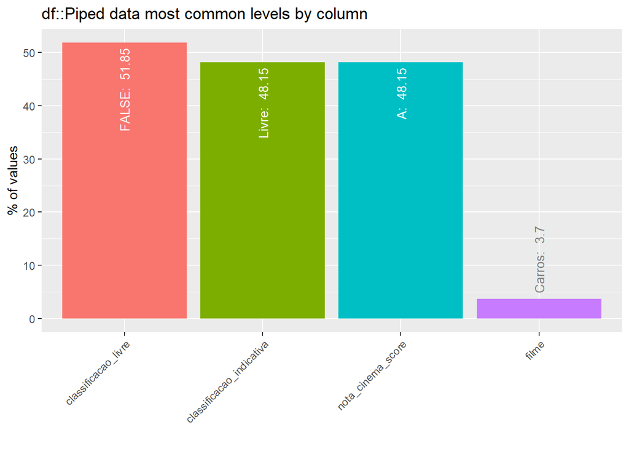

```r
dados_pixar %>% inspectdf::inspect_imb() %>% inspectdf::show_plot()
```

```r
dados_pixar %>% inspectdf::inspect_num()
```

```
## # A tibble: 2 × 10
##   col_name             min    q1 median  mean    q3   max    sd pcnt_na hist
##   <chr>              <dbl> <dbl>  <dbl> <dbl> <dbl> <dbl> <dbl>   <dbl> <named >
## 1 duracao               81    95    100 105.  106     155  16.8    7.41 <tibble>
## 2 nota_rotten_tomat…    40    84     96  89.2  97.5   100  14.2   14.8  <tibble>
```

## skimr

Em português skim significa algo como “tirar a nata” de algo, e isto é exatamente o que este pacote faz, visto que nos permite uma visão geral de toda a base, com uma serie de estatísticas importantes, respeitando o tipo de cada coluna:

```r
#skimr::
dados_pixar %>%  skimr::skim()
```

Data summary

| Name | Piped data |
| --- | --- |
| Number of rows | 27 |
| Number of columns | 7 |
| _______________________ |  |
| Column type frequency: |  |
| character | 1 |
| Date | 1 |
| factor | 2 |
| logical | 1 |
| numeric | 2 |
| ________________________ |  |
| Group variables | None |

**Variable type: character**

| skim_variable | n_missing | complete_rate | min | max | empty | n_unique | whitespace |
| --- | --- | --- | --- | --- | --- | --- | --- |
| filme | 1 | 0.96 | 4 | 35 | 0 | 26 | 0 |

**Variable type: Date**

| skim_variable | n_missing | complete_rate | min | max | median | n_unique |
| --- | --- | --- | --- | --- | --- | --- |
| data_lancamento | 0 | 1 | 1995-11-22 | 2023-06-16 | 2013-06-21 | 27 |

**Variable type: factor**

| skim_variable | n_missing | complete_rate | ordered | n_unique | top_counts |
| --- | --- | --- | --- | --- | --- |
| classificacao_indicativa | 0 | 1.00 | FALSE | 4 | Liv: 13, Ori: 10, N/A: 3, Não: 1 |
| nota_cinema_score | 5 | 0.81 | TRUE | 3 | A: 13, A+: 7, A-: 2 |

**Variable type: logical**

| skim_variable | n_missing | complete_rate | mean | count |
| --- | --- | --- | --- | --- |
| classificacao_livre | 0 | 1 | 0.48 | FAL: 14, TRU: 13 |

**Variable type: numeric**

| skim_variable | n_missing | complete_rate | mean | sd | p0 | p25 | p50 | p75 | p100 | hist |
| --- | --- | --- | --- | --- | --- | --- | --- | --- | --- | --- |
| duracao | 2 | 0.93 | 104.84 | 16.78 | 81 | 95 | 100 | 106.0 | 155 | ▅▇▂▁▁ |
| nota_rotten_tomatoes | 4 | 0.85 | 89.17 | 14.15 | 40 | 84 | 96 | 97.5 | 100 | ▁▁▂▂▇ |

## mais pacotes

No R você irá encontrar dezenas de pacotes com o objetivo de “facilitar” a sua visão, particularmente para a exploração descritiva de dados. Bibliotecas como: `visdat`, `naniar`, `DataExplorer`, entre tantas outras. Que tal explorar um pouco por aí?

# Tipos de dados vs. objetivos de análise